# SOMMD Notebook 1

This is A Notebook that explain how to use the SOMMD package to perform analysis of molecular dynamics simulations.

Load kohonen and SOMMD packages

```r
library(kohonen)
devtools::load_all("..")
```

```
ℹ Loading SOMMD
```

Read simulation files from pdb and xtc files. Since we have more replicas we will read all the simulations with a for cycle, and append the replicas with the cat_trj function.

```r
#Read the first replica
trj <- read.trj(trjfile="../data/Medium_Dataset/REP_001.xtc", topfile="../data/Medium_Dataset/ref.pdb")
#Append all other trj files
for(trj_file in list.files("../data/Medium_Dataset/", pattern = "*.xtc")[-1]){
  rep <- read.trj(trjfile=paste("../data/Medium_Dataset/", trj_file, sep=""),
                  topfile="../data/Medium_Dataset/ref.pdb")
  trj <- cat.trj(trj, rep)
}
```

## SOM Training

At this point you have to choose a set of descriptors that will be used for the training of the SOM. SOMMD have a series of built-in function that facilitate the computation of some common descriptors. In the present case we want to study an unfolding process, and to describe the protein conformation during the unfolding the Cbeta pairwise distances are a valid choice [@Motta2021]. Among these distances, the most interesting ones are those between atoms forming a contact in the native (folded) conformation. These distances can be selected using the native_contacts function.

```r
#Read reference pdb with native conformation
pdb <- bio3d::read.pdb("../data/Medium_Dataset/ref.pdb")
#Select only Cbeta atoms to perform the analysis
sele.atoms <- which(trj$top$elety=="CB")
#Choose only native contacts
sele.dists <- native.cont(struct=pdb, distance=1.0, atoms=sele.atoms)
#Compute distances for SOM training.
DIST <- calc.distances(trj, mol.2=FALSE, sele=sele.dists, atoms=sele.atoms)
```

At this point the computed distances can be used to train the SOM using the kohonen function. We will train a sheet-shaped (non toroidal) 8x8 SOM with hexagonal neurons.

```r
SOM <- kohonen::som(DIST, grid = somgrid(8, 8, "hexagonal",
                                         neighbourhood.fct="gaussian", toroidal=FALSE),
                    dist.fcts="euclidean", rlen=500, mode='pbatch')
```

We can inspect the shape of the SOM looking at the U-Matrix

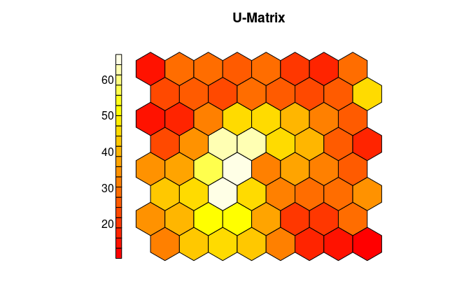

```r
plot(SOM, type = 'dist.neighbours', heatkey = TRUE, shape='straight', main="U-Matrix")
```

This plot is telling us regions of the map with high gradient of difference (yellow/white), and regions that contain neurons similar to each other (red).

## Clustering of Neurons

To further group neurons similar to each other into clusters an agglomerative clustering method can be applied to the neuron vectors. As all the hierarchical clustering methods, one should provide the number of clusters into which the neurons will be divided. To choose a reasonable number of clusters one can look at the silhouette profiles:

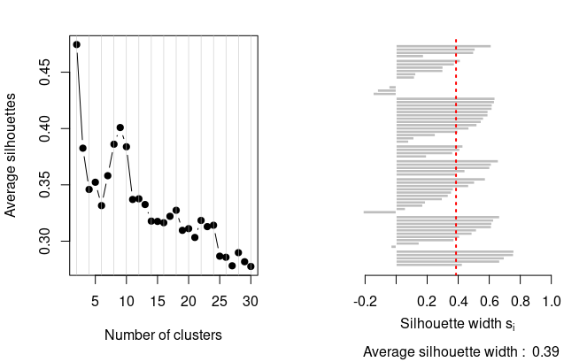

```r
par(mfrow=c(1,2))
#Plot the silhouette score
plot.silhouette.score(SOM, clust_method="complete", interval=seq(2,30))
#Plot the silhouette profile for 8 number of clusters
plot.silhouette.profile(SOM, Nclus=8, clust_method="complete")
```

From this plot one can choose a good value for the number of clusters and plot the resulting SOM. This should ideally be a maximum in the average silhouette score plot, but looking at the single silhouette profiles one can further inspect the quality of the clusters.

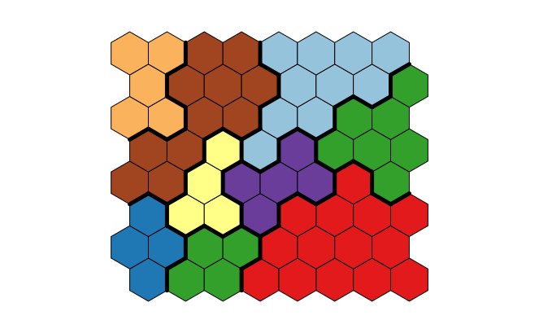

```r
#Divide the SOM in the selected number of clusters
SOM.hc <- cutree(hclust(dist(SOM$codes[[1]], method="euclidean"), method="complete"), 8)
#Choose a pleasing to the eye set of colors
COL.SCALE <- c("#1f78b4", "#33a02c", "#e31a1c", "#ffff88", "#6a3d9a",
               "#a0451f", "#96c3dc", "#fbb25c", "#ff7f00", "#bea0cc",
               "#747474", "#f88587", "#a4db77")
#Plot the SOM colored by clusters
plot(SOM, type = "mapping", bgcol=COL.SCALE[SOM.hc], col=rgb(0,0,0,0), shape='straight', main="")
add.cluster.boundaries(SOM, SOM.hc, lwd=5)
```

Many personalizations can be applied on the plotted SOM. For example one can decide to add the number of neurons:

```r
#Plot the SOM with neuron numbers
plot(SOM, type = "mapping", bgcol=COL.SCALE[SOM.hc], col=rgb(0,0,0,0), shape='straight', main="")
add.cluster.boundaries(SOM, SOM.hc, lwd=5)
```

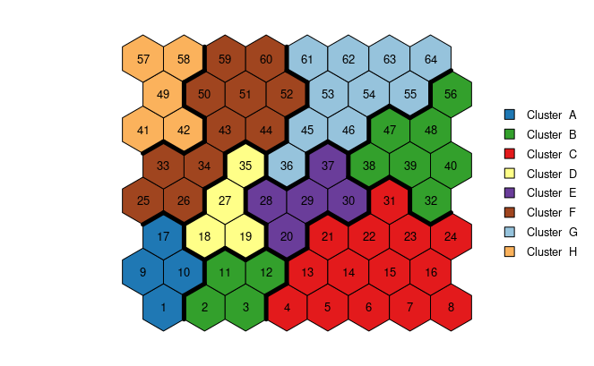

```r
som.add.numbers(SOM, scale=0.5, col="black")
som.add.clusters.legend(N.clus=8, color.scale=COL.SCALE)
```

## Extraction of representative frames

To inspect the conformations associated to each neuron, a representative structure can be extracted from the SOM:

```r
#Get a vector of representative frames for each neuron
NEUR_repres <- neur.representatives(SOM)
cat("Frames representatives of neurons: ")
```

```
Frames representatives of neurons:
```

```r
cat(NEUR_repres)
```

```
3022 2987 2940 2904 2881 1263 1239 3627 3043 3449 NA NA 1699 1681 467 1253 3469 NA 210 NA 1715 2492 3304 3716 687 289 258 174 546 528 3725 1333 1131 711 NA 584 1770 NA 2150 3365 349 340 3929 667 NA 1817 3791 1372 777 2328 1501 2289 3863 2635 3808 3405 1195 3969 2316 3494 1871 1841 2622 602
```

```r
#Get representatives for each cluster
CL_repres <- cluster.representatives(SOM, SOM.hc)
cat("\n\nNeurons representatives of each cluster: ")
```

```
Neurons representatives of each cluster:
```

```r
cat(CL_repres$neurons)
```

```
10 40 6 27 29 59 54 58
```

```r
cat("\n\nFrames representatives of each cluster: ")
```

```
Frames representatives of each cluster:
```

```r
cat(CL_repres$frames)
```

```
3449 3365 1263 258 546 2316 2635 3969
```

If NA values appear, they are associated to empty neurons/clusters

To extract a conformation saving the pdb structure file simply use the trj2pdb function:

```r
#Estract the representative conformation of Neuron 8
trj2pdb(traj = trj, frame=NEUR_repres[8], filename = "../output/Neuron_8.pdb")

#Estract the representative conformation of Cluster B
trj2pdb(traj = trj, frame=CL_repres$frames["B"], filename = "../output/Cluster_B.pdb")
```

## Representation of properties on SOM

A property of the neurons can be represented using circles with the size proportional to the value of a property of the neuron. For example one can use neurons to represent the population of each neuron:

```r
#Plot the SOM with circles with size proportional to the neuron population
plot(SOM, type = "mapping", bgcol=COL.SCALE[SOM.hc], col=rgb(0,0,0,0), shape='straight', main="")
add.cluster.boundaries(SOM, SOM.hc, lwd=5)
```

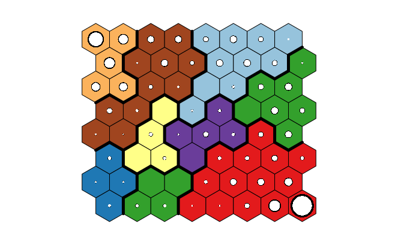

```r
population <- neur.population(SOM)
SOM.add.circles(SOM, population, scale=0.9)
```

Instead of using circles to plot a property over the plot, you may use colors-scales. This is usually done to represent the average property of frames belonging to each neurons. In that case, simply compute the average property for each neuron and then color the map accordingly. Here we compute the distance between the Calpha atoms of the C- and N- terminal ends of the domain and plot this property:

```r
#Select the index of the first and last CA atoms
Terminals <- c(head(which(trj$top$elety=="CA"),1), tail(which(trj$top$elety=="CA"),1))
#Compute distances between these two atoms in every frame of the simulation
Term_dist <- apply(trj$coord[Terminals,,], 3, dist)
#Compute average property value for each neuron
Neur.avg.d <- average.neur.property(SOM, Term_dist)
par(mfrow=c(1,2))

#Plot the SOM with circles with size proportional to the average distance values
plot(SOM, type = "mapping", bgcol=COL.SCALE[SOM.hc], col=rgb(0,0,0,0), shape='straight', main="")
add.cluster.boundaries(SOM, SOM.hc, lwd=5)
```

```r
SOM.add.circles(SOM, Neur.avg.d, scale=0.5)
#Plot the SOM colored according to the average property value of each neuron
plot(SOM, type = "property", property=Neur.avg.d, shape='straight', palette.name=colorRampPalette(c("blue", "yellow", "red")), main="")
```

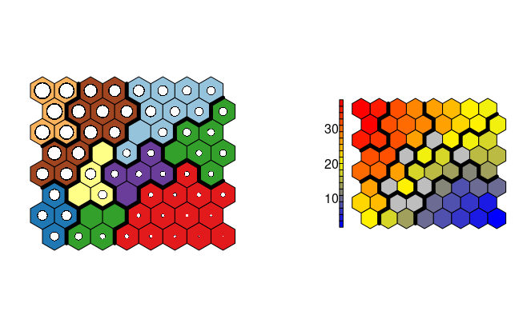

```r
add.cluster.boundaries(SOM, SOM.hc, lwd=5)
```

Any external property can be used (like the pulling force applied during steered MD) provided that every property value is associated to a frame.

## Trace Pathways

At this point one can trace the pathways sampled during each replica on the SOM. This can be done using the function trace_path. This function draw the pathway followed by a simulation on the SOM. In order to simplify the plot of pathways from different replicas, the trj object contains the information of start and end of each replica merged with cat_trj in trj$start and trj$end. Using this information one can plot the pathway of a specific replica:

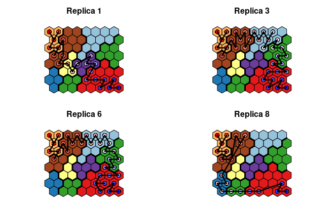

```r
#Plot the SOM colored by clusters
par(mfrow=c(2,2))
for(rep in c(1,3,6,8)){
  plot(SOM, type = "mapping", bgcol=COL.SCALE[SOM.hc], col=rgb(0,0,0,0),
       shape='straight', main=paste("Replica ", rep, sep=""))
  add.cluster.boundaries(SOM, SOM.hc, lwd=3)
  trace.path(SOM, start=trj$start, end=trj$end, N=rep, scale=0.5)
}
```

The type of sampled pathways can be inspected using a pathway clustering method:

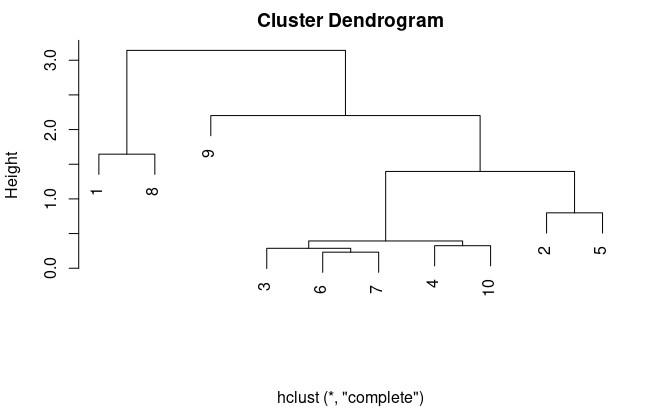

```r
path.clust <- cluster.pathways(SOM, start=trj$start, end=trj$end, time.dep="dependent")
plot(path.clust, xlab="")
```

This shows the similarity between pathways sampled in different replicas.

## **Representing SOM as a graph network**

Using the information from the transition matrix of the simulations it is also possible to build a graph network that represent all the possible pathways sampled.

```r
#Compute transition matrix
Tr_mat <- comp.trans.mat(SOM$unit.classif, start=trj$start)
#Convert the matrix to an igraph network
d <- Matrix2Network(Tr_mat)
#Remove the self transitions
d_nodiag <- rm.net.diag(d)
net <- Network2Graph(d_nodiag, SOM, SOM.hc, COL.SCALE)
```

Using the igraph package several representation of the SOM can be obtained:

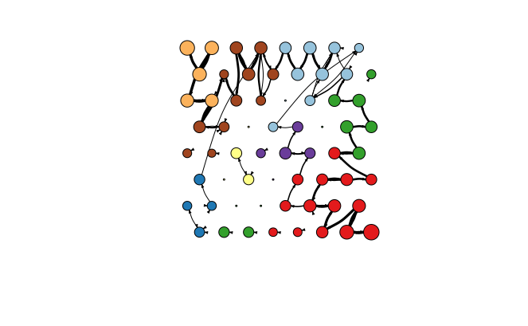

```r
library(igraph)
#edge.start <- ends(net, es=E(net), names=F)[,1]
#edge.col <- V(net)$color[edge.start]
#Plot network with the SOM layout
plot(net, edge.arrow.size=E(net)$width/5, edge.curved=0.17, edge.color='black', vertex.label="", layout=SOM$grid$pts)
```

However, optimal disposition of vertex can be used. Several algorithm exist able to estimate optimal network vertices placement on the plane. Here we will use the force-directed layout algorithm by Fruchterman and Reingold.

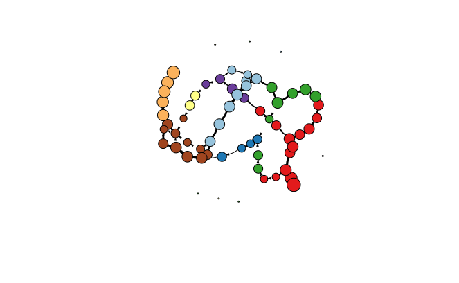

```r
coords = layout_with_fr(net, coords=SOM$grid$pts)
plot(net, edge.arrow.size=E(net)$width/5, edge.curved=0.17, edge.color='black', vertex.label="", layout=coords)
```

Note that since the layout algorithm is not deterministic, you will obtain a different vertex disposition every time you rerun the layout_with_fr() command. You may also try to run the command several time to search for a clear vertex disposition.

You may also want to perform a kinetic-like clustering using a community detection method. Among those available in igraph, the walktrap method allows to treat biderectional graph. This function tries to find densely connected subgraphs, also called communities in a graph via random walks. The idea is that short random walks tend to stay in the same community.

```r
CL_walktrap <- cluster_walktrap(net)
COL <- COL.SCALE[membership(CL_walktrap)]
par(mfrow=c(1,2))
plot(SOM, type = "mapping", bgcol=COL, col=rgb(0,0,0,0), shape='straight', main="")
add.cluster.boundaries(SOM, SOM.hc, lwd=3)
```

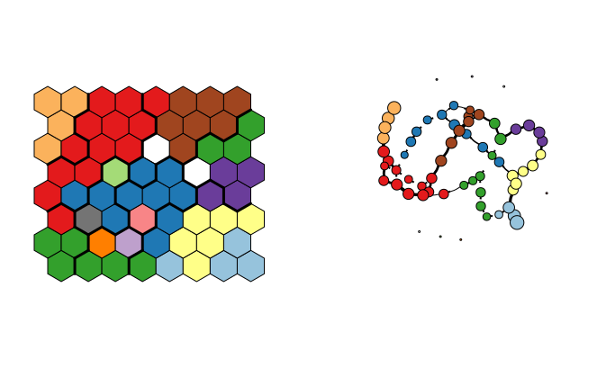

```r
plot(net, edge.arrow.size=E(net)$width/10, edge.curved=0.17, vertex.color=COL, edge.color='black', vertex.label="", layout=coords)
```

Here neurons are diveded according to the transition probability instead of their geometric similarity.

To map a property to a graph, simply set the color of each node according to a colorscale. Start computing a property

```r
#Select the index of the first and last CA atoms
Terminals <- c(head(which(trj$top$elety=="CA"),1), tail(which(trj$top$elety=="CA"),1))
#Compute distances between these two atoms in every frame of the simulation
Term_dist <- apply(trj$coord[Terminals,,], 3, dist)
#Compute average property value for each neuron
Neur.avg.d <- average.neur.property(SOM, Term_dist)
```

And then set the color of each neuron:

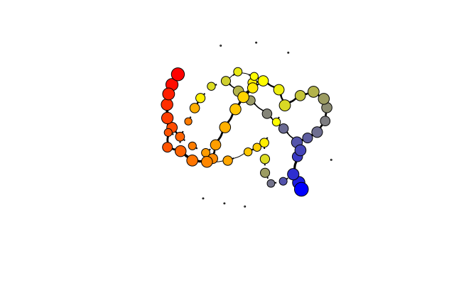

```r
#Set the color scale
col.palette <- colorRampPalette(c("blue", "yellow", "red"))(200)
#Convert the average property to the colors
COL <- map2color(Neur.avg.d, col.palette)
#Do the plot
plot(net, edge.arrow.size=E(net)$width/10, edge.curved=0.17, vertex.color=COL, edge.color='black', vertex.label="", layout=coords)
```

## **Mapping of new data on an existing SOM**

If you are interested in using a trained SOM to represent a new set of data (additional simulations not used during the training) you can use the map.data() function.

```r
#Read additional simulations
trj2 <- read.trj(trjfile="../data/Additional_Dataset/REP_011.xtc", topfile="../data/Medium_Dataset/ref.pdb")
#Append all other trj files
for(trj_file in list.files("../data/Additional_Dataset/", pattern = "*.xtc")[-1]){
  rep <- read.trj(trjfile=paste("../data/Additional_Dataset/", trj_file, sep=""),
                  topfile="../data/Medium_Dataset/ref.pdb")
  trj2 <- cat.trj(trj2, rep)
}
#Compute distances (the same used for SOM training)
DIST2 <- calc.distances(trj2, mol.2=FALSE, sele=sele.dists, atoms=sele.atoms)
#Map new data on the existing SOM
SOM_new <- map.data(SOM=SOM, X=DIST2)
```

At this point you can use the new SOM object (SOM_new) to generate plot for the new set of simulations:

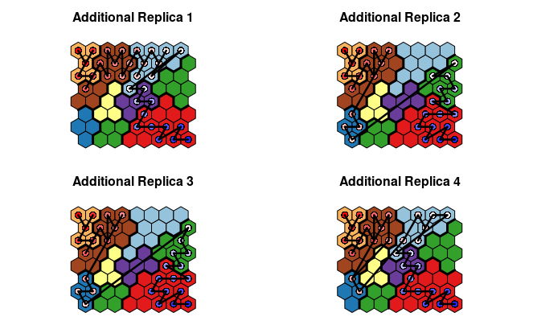

```r
#Plot the SOM colored by clusters
par(mfrow=c(2,2))
for(rep in c(1,2,3,4)){
  plot(SOM_new, type = "mapping", bgcol=COL.SCALE[SOM.hc], col=rgb(0,0,0,0),
       shape='straight', main=paste("Additional Replica ", rep, sep=""))
  add.cluster.boundaries(SOM_new, SOM.hc, lwd=3)
  trace.path(SOM_new, start=trj2$start, end=trj2$end, N=rep, scale=0.5)
}
```

```r
#Plot the SOM with circles with size proportional to the neuron population
plot(SOM_new, type = "mapping", bgcol=COL.SCALE[SOM.hc], col=rgb(0,0,0,0), shape='straight', main="")
add.cluster.boundaries(SOM_new, SOM.hc, lwd=5)
```

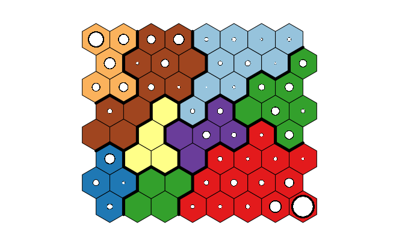

```r
population <- neur.population(SOM_new)
SOM.add.circles(SOM, population, scale=0.9)
```